# SAE 3-01 : Application MonVoyage

## 4. Meteo (API Open-Meteo)

```python
# Collecte de la meteo via API Open-Meteo
print("Collecte des previsions meteo via API Open-Meteo...")
meteo_paris = mv.collecter_meteo(paris, nb_jours=3)

if meteo_paris:
    print(f"OK - {len(meteo_paris)} jours de previsions collectes\n")

    # Creation d'un DataFrame pandas pour affichage
    data_meteo = {
        'Date': [m.date for m in meteo_paris],
        'Temp Min (C)': [m.temp_min for m in meteo_paris],
        'Temp Max (C)': [m.temp_max for m in meteo_paris],
        'Precipitations (mm)': [m.precipitation for m in meteo_paris]
    }
    df_meteo = pd.DataFrame(data_meteo)

    print("Tableau des previsions meteo :")
    display(df_meteo)

    # Export en CSV
    mv.exporter_meteo_csv(meteo_paris, "data/paris_meteo.csv")
else:
    print("ERREUR lors de la collecte de la meteo")
```

```
Collecte des previsions meteo via API Open-Meteo...
Meteo collectee: 3 jours
OK - 3 jours de previsions collectes

Tableau des previsions meteo :
```

|  | Date | Temp Min (C) | Temp Max (C) | Precipitations (mm) |
| --- | --- | --- | --- | --- |
| 0 | 2026-01-23 | 5.9 | 10.3 | 4.90 |
| 1 | 2026-01-24 | 2.7 | 8.9 | 0.00 |
| 2 | 2026-01-25 | 4.7 | 7.7 | 3.42 |

```
Meteo exportee dans data/paris_meteo.csv
```

### Visualisation graphique de la meteo

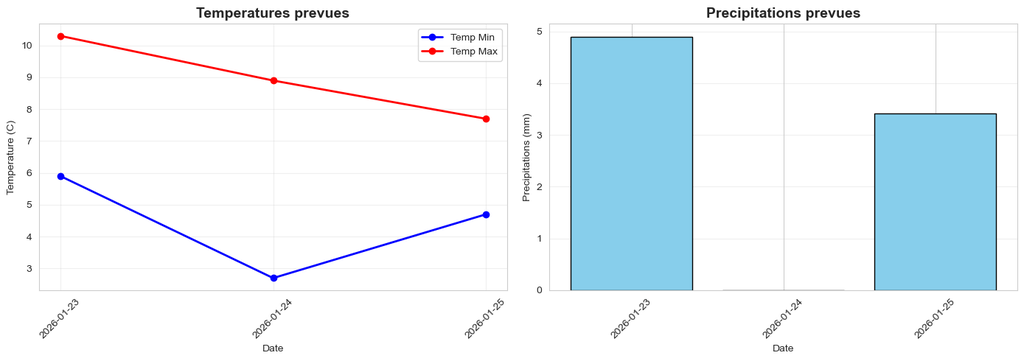

```
Temperature moyenne : 9.0 C
Precipitations totales : 8.3 mm
```

```python
# Graphiques des temperatures et precipitations
if meteo_paris:
    fig, ax = plt.subplots(1, 2, figsize=(14, 5))

    # Temperatures
    ax[0].plot(df_meteo['Date'], df_meteo['Temp Min (C)'], marker='o', label='Temp Min', color='blue', linewidth=2)
    ax[0].plot(df_meteo['Date'], df_meteo['Temp Max (C)'], marker='o', label='Temp Max', color='red', linewidth=2)
    ax[0].set_title('Temperatures prevues', fontsize=14, fontweight='bold')
    ax[0].set_xlabel('Date')
    ax[0].set_ylabel('Temperature (C)')
    ax[0].legend()
    ax[0].grid(True, alpha=0.3)
    ax[0].tick_params(axis='x', rotation=45)

    # Precipitations
    ax[1].bar(df_meteo['Date'], df_meteo['Precipitations (mm)'], color='skyblue', edgecolor='black')
    ax[1].set_title('Precipitations prevues', fontsize=14, fontweight='bold')
    ax[1].set_xlabel('Date')
    ax[1].set_ylabel('Precipitations (mm)')
    ax[1].tick_params(axis='x', rotation=45)
    ax[1].grid(True, alpha=0.3, axis='y')

    plt.tight_layout()
    plt.show()

    print(f"\nTemperature moyenne : {sum([m.temp_max for m in meteo_paris])/len(meteo_paris):.1f} C")
    print(f"Precipitations totales : {sum([m.precipitation for m in meteo_paris]):.1f} mm")
```

## 5. Hotels (API Overpass - OpenStreetMap)

Collecte des hotels disponibles a Paris

```python
# Collecte des hotels via API Overpass (OpenStreetMap)
print("Collecte des hotels via API Overpass (OpenStreetMap)...")
hotels_paris = mv.collecter_hotels(paris, limite=20)

if hotels_paris:
    print(f"OK - {len(hotels_paris)} hotels collectes\n")

    # Creation d'un DataFrame pandas
    data_hotels = {
        'Nom': [h.nom for h in hotels_paris],
        'Etoiles': [f"{h.stars} etoiles" if h.stars else 'NC' for h in hotels_paris],
        'Prix estime/nuit': [f"{h.prix_estime} euros" for h in hotels_paris],
        'Latitude': [round(h.latitude, 4) for h in hotels_paris],
        'Longitude': [round(h.longitude, 4) for h in hotels_paris]
    }
    df_hotels = pd.DataFrame(data_hotels)

    print("Tableau des hotels (10 premiers) :")
    display(df_hotels.head(10))

    # Export en CSV
    mv.exporter_hotels_csv(hotels_paris, "data/paris_hotels.csv")
    print(f"\nFichier CSV exporte : data/paris_hotels.csv ({len(hotels_paris)} lignes)")
else:
    print("ERREUR - Aucun hotel trouve")
```

```
Collecte des hotels via API Overpass (OpenStreetMap)...
Hotels collectes: 20
OK - 20 hotels collectes

Tableau des hotels (10 premiers) :
```

|  | Nom | Etoiles | Prix estime/nuit | Latitude | Longitude |
| --- | --- | --- | --- | --- | --- |
| 0 | Ibis | NC | 80 euros | 48.8403 | 2.3156 |
| 1 | Hôtel Saint-Honoré | 3 etoiles | 110 euros | 48.8612 | 2.3436 |
| 2 | Hôtel Montpensier | 2 etoiles | 75 euros | 48.8644 | 2.3363 |
| 3 | Hôtel Louvre Bon Enfants | 3 etoiles | 110 euros | 48.8629 | 2.3382 |
| 4 | Hôtel Costes | NC | 80 euros | 48.8663 | 2.3280 |
| 5 | Résidence les Boulevards | 4 etoiles | 160 euros | 48.8697 | 2.3487 |
| 6 | Hôtel Marie | NC | 80 euros | 48.8696 | 2.3487 |
| 7 | Hôtel du Loiret | 3 etoiles | 110 euros | 48.8569 | 2.3553 |
| 8 | Charles V | NC | 80 euros | 48.8535 | 2.3618 |
| 9 | Hôtel de la Place des Vosges | NC | 80 euros | 48.8544 | 2.3652 |

```
Hotels exportes dans data/paris_hotels.csv

Fichier CSV exporte : data/paris_hotels.csv (20 lignes)
```

### Distribution des prix d'hotels

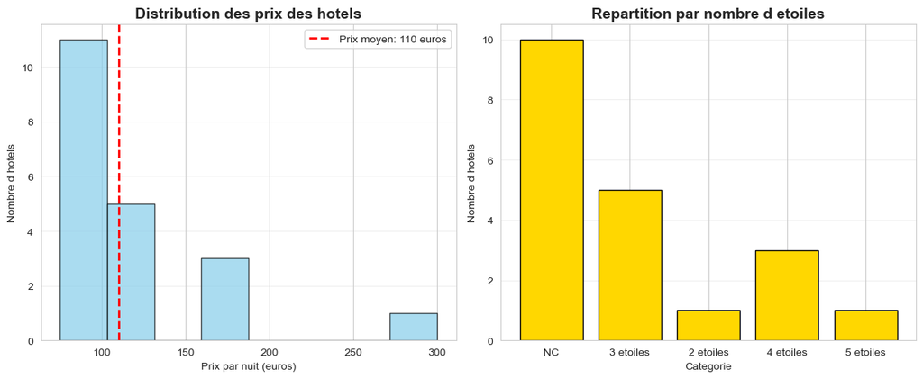

```
Statistiques :
   Prix minimum : 75 euros/nuit
   Prix maximum : 300 euros/nuit
   Prix moyen : 110.25 euros/nuit
```

```python
# Analyse des prix d'hotels
if hotels_paris:
    prix_hotels = [h.prix_estime for h in hotels_paris]
    prix_moyen = sum(prix_hotels) / len(prix_hotels)

    plt.figure(figsize=(12, 5))

    # Histogramme
    plt.subplot(1, 2, 1)
    plt.hist(prix_hotels, bins=8, color='skyblue', edgecolor='black', alpha=0.7)
    plt.axvline(prix_moyen, color='red', linestyle='--', linewidth=2, label=f'Prix moyen: {prix_moyen:.0f} euros')
    plt.title('Distribution des prix des hotels', fontsize=14, fontweight='bold')
    plt.xlabel('Prix par nuit (euros)')
    plt.ylabel('Nombre d hotels')
    plt.legend()
    plt.grid(True, alpha=0.3, axis='y')

    # Repartition par etoiles
    plt.subplot(1, 2, 2)
    etoiles_count = {}
    for h in hotels_paris:
        key = f"{h.stars} etoiles" if h.stars else "NC"
        etoiles_count[key] = etoiles_count.get(key, 0) + 1

    plt.bar(etoiles_count.keys(), etoiles_count.values(), color='gold', edgecolor='black')
    plt.title('Repartition par nombre d etoiles', fontsize=14, fontweight='bold')
    plt.xlabel('Categorie')
    plt.ylabel('Nombre d hotels')
    plt.grid(True, alpha=0.3, axis='y')

    plt.tight_layout()
    plt.show()

    print(f"\nStatistiques :")
    print(f"   Prix minimum : {min(prix_hotels)} euros/nuit")
    print(f"   Prix maximum : {max(prix_hotels)} euros/nuit")
    print(f"   Prix moyen : {prix_moyen:.2f} euros/nuit")
```

```python
# Collecte des restaurants via API Overpass
print("Collecte des restaurants via API Overpass (OpenStreetMap)...")
restaurants_paris = mv.collecter_restaurants(paris, limite=30)

if restaurants_paris:
    print(f"OK - {len(restaurants_paris)} restaurants collectes\n")

    # Creation d'un DataFrame
    data_restos = {
        'Nom': [r.nom for r in restaurants_paris],
        'Type': [r.type_lieu for r in restaurants_paris],
        'Cuisine': [r._cuisine if r._cuisine else 'Non specifie' for r in restaurants_paris],
        'Prix estime/repas': [f"{r.prix_estime} euros" for r in restaurants_paris]
    }
    df_restos = pd.DataFrame(data_restos)

    print("Tableau des restaurants (10 premiers) :")
    display(df_restos.head(10))

    # Export en CSV
    mv.exporter_restaurants_csv(restaurants_paris, "data/paris_restaurants.csv")
    print(f"\nFichier CSV exporte : data/paris_restaurants.csv ({len(restaurants_paris)} lignes)")
else:
    print("ERREUR - Aucun restaurant trouve")
```

```
Collecte des restaurants via API Overpass (OpenStreetMap)...
Restaurants collectes: 30
OK - 30 restaurants collectes

Tableau des restaurants (10 premiers) :
```

|  | Nom | Type | Cuisine | Prix estime/repas |
| --- | --- | --- | --- | --- |
| 0 | The Village Terrazza | restaurant | pizza | 25 euros |
| 1 | Le Severo | restaurant | french | 25 euros |
| 2 | Uno | restaurant | italian;pizza | 25 euros |
| 3 | La Crypte Polska | restaurant | Non specifie | 25 euros |
| 4 | Le Café Marly | cafe | Non specifie | 8 euros |
| 5 | Mystery Cuisine | restaurant | Non specifie | 25 euros |
| 6 | Chez Denise | restaurant | french | 25 euros |
| 7 | La Robe et le Palais | restaurant | bistro;french | 25 euros |
| 8 | Macéo | restaurant | Non specifie | 25 euros |
| 9 | Le Petit Marché | restaurant | french | 25 euros |

```
Restaurants exportes dans data/paris_restaurants.csv

Fichier CSV exporte : data/paris_restaurants.csv (30 lignes)
```

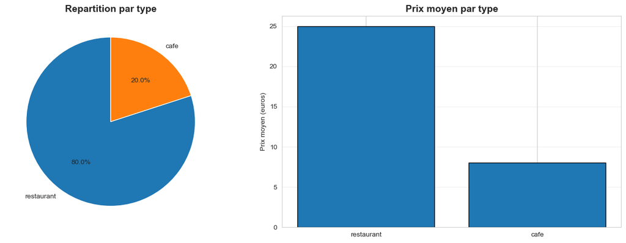

```python
# Analyse par type de restaurant
if restaurants_paris:
    # Comptage par type
    types_resto = {}
    for r in restaurants_paris:
        types_resto[r.type_lieu] = types_resto.get(r.type_lieu, 0) + 1

    fig, ax = plt.subplots(1, 2, figsize=(14, 5))

    # Camembert
    ax[0].pie(types_resto.values(), labels=types_resto.keys(), autopct='%1.1f%%', startangle=90)
    ax[0].set_title('Repartition par type', fontsize=14, fontweight='bold')

    # Prix moyens par type
    prix_par_type = {}
    for r in restaurants_paris:
        if r.type_lieu not in prix_par_type:
            prix_par_type[r.type_lieu] = []
        prix_par_type[r.type_lieu].append(r.prix_estime)

    types = list(prix_par_type.keys())
    prix_moyens = [sum(prix_par_type[t])/len(prix_par_type[t]) for t in types]

    ax[1].bar(types, prix_moyens, edgecolor='black')
    ax[1].set_title('Prix moyen par type', fontsize=14, fontweight='bold')
    ax[1].set_ylabel('Prix moyen (euros)')
    ax[1].grid(True, alpha=0.3, axis='y')

    plt.tight_layout()
    plt.show()
```

```python
# Collecte des attractions via API Overpass
print("Collecte des attractions touristiques via API Overpass...")
attractions_paris = mv.collecter_attractions(paris, limite=25)

if attractions_paris:
    print(f"OK - {len(attractions_paris)} attractions collectees\n")

    # Creation d'un DataFrame
    data_attractions = {
        'Nom': [a.nom for a in attractions_paris],
        'Type': [a.type_lieu for a in attractions_paris],
        'Payant': ['Oui' if a.est_payant() else 'Non' for a in attractions_paris],
        'Prix estime': [f"{a.prix_estime} euros" for a in attractions_paris]
    }
    df_attractions = pd.DataFrame(data_attractions)

    print("Tableau des attractions (10 premieres) :")
    display(df_attractions.head(10))

    # Export en CSV
    mv.exporter_attractions_csv(attractions_paris, "data/paris_attractions.csv")
    print(f"\nFichier CSV exporte : data/paris_attractions.csv ({len(attractions_paris)} lignes)")
else:
    print("ERREUR - Aucune attraction trouvee")
```

```
Collecte des attractions touristiques via API Overpass...
Attractions collectees: 25
OK - 25 attractions collectees

Tableau des attractions (10 premieres) :
```

|  | Nom | Type | Payant | Prix estime |
| --- | --- | --- | --- | --- |
| 0 | Musée de l'Armée | museum | Non | 0 euros |
| 1 | Point zéro des Routes de France | attraction | Non | 0 euros |
| 2 | Musée de l'Assistance Publique Hôpitaux de Paris | museum | Non | 0 euros |
| 3 | Musée des Arts Décoratifs | museum | Non | 0 euros |
| 4 | Musée des Arts et Métiers | museum | Oui | 12 euros |
| 5 | Musée national Gustave Moreau | museum | Non | 0 euros |
| 6 | Musée Grévin | museum | Oui | 12 euros |
| 7 | Musée Edith Piaf | museum | Oui | 12 euros |
| 8 | Espace Dali | museum | Non | 0 euros |
| 9 | Maison de Victor Hugo | museum | Non | 0 euros |

```
Attractions exportees dans data/paris_attractions.csv

Fichier CSV exporte : data/paris_attractions.csv (25 lignes)
```

## 8. Transport

```python
# Creation du transport
transport = mv.Transport(
    type_transport="train",
    ville_depart="Lille",
    ville_arrivee="Paris",
    prix_aller=35,
    prix_retour=35
)

print("Transport defini :")
print(f"   Type : {transport.type_transport}")
print(f"   De {transport._ville_depart} vers {transport._ville_arrivee}")
print(f"   Prix aller : {transport._prix_aller} euros")
print(f"   Prix retour : {transport._prix_retour} euros")
print(f"   Prix total par personne : {transport.prix_total} euros")
print(f"   Prix total pour 2 personnes : {transport.prix_total * 2} euros")
```

```
Transport defini :
   Type : train
   De Lille vers Paris
   Prix aller : 35 euros
   Prix retour : 35 euros
   Prix total par personne : 70 euros
   Prix total pour 2 personnes : 140 euros
```

## 9. Creation du voyage complet

```python
# Creation du voyage
voyage_paris = mv.Voyage(
    utilisateur=utilisateur,
    ville=paris,
    date_debut="2026-02-10",
    nb_jours=3,
    nb_personnes=2
)

# Ajout du transport
voyage_paris.transport = transport

# Ajout des donnees collectees
for h in hotels_paris:
    voyage_paris.ajouter_hotel(h)

for r in restaurants_paris:
    voyage_paris.ajouter_restaurant(r)

for a in attractions_paris:
    voyage_paris.ajouter_attraction(a)

for m in meteo_paris:
    voyage_paris.ajouter_meteo(m)

print("Voyage cree :")
print(voyage_paris)
```

```
Voyage cree :
Voyage à Paris pour 2 personne(s) - 3 jours
```

## 10. Programme jour par jour

```python
# Creation du programme
programme = voyage_paris.creer_programme()

print("="*60)
print("PROGRAMME DU VOYAGE")
print("="*60)

# Pour chaque jour, on assigne des POIs
for jour in programme.jours:
    print(f"\nJOUR {jour.numero} - {jour.date}")
    print("-" * 60)

    # Assigner un hotel
    if hotels_paris:
        jour.hotel = hotels_paris[0]
        print(f"Hotel : {jour.hotel.nom} ({jour.hotel.stars} etoiles - {jour.hotel.prix_estime} euros/nuit)")

    # Assigner 3 restaurants pour la journee (petit-dej, dejeuner, diner)
    print(f"\nRestaurants :")
    for i in range(min(3, len(restaurants_paris))):
        idx = (i + (jour.numero-1)*3) % len(restaurants_paris)
        jour.ajouter_restaurant(restaurants_paris[idx])
        resto = jour.restaurants[i]
        print(f"  - {resto.nom} ({resto.type_lieu}) - {resto.prix_estime} euros")

    # Assigner 2 attractions pour la journee
    print(f"\nAttractions :")
    for i in range(min(2, len(attractions_paris))):
        idx = (i + (jour.numero-1)*2) % len(attractions_paris)
        jour.ajouter_attraction(attractions_paris[idx])
        attr = jour.attractions[i]
        payant = "Payant" if attr.est_payant() else "Gratuit"
        print(f"  - {attr.nom} ({attr.type_lieu}) - {payant} ({attr.prix_estime} euros)")

    # Meteo du jour
    if jour.numero <= len(meteo_paris):
        meteo = meteo_paris[jour.numero - 1]
        print(f"\nMeteo : {meteo.temp_min}C / {meteo.temp_max}C - Pluie : {meteo.precipitation}mm")

print("\n" + "="*60)
```

```
============================================================
PROGRAMME DU VOYAGE
============================================================

JOUR 1 - 2026-02-10
------------------------------------------------------------
Hotel : Ibis (None etoiles - 80 euros/nuit)

Restaurants :
  - The Village Terrazza (restaurant) - 25 euros
  - Le Severo (restaurant) - 25 euros
  - Uno (restaurant) - 25 euros

Attractions :
  - Musée de l'Armée (museum) - Gratuit (0 euros)
  - Point zéro des Routes de France (attraction) - Gratuit (0 euros)

Meteo : 5.9C / 10.3C - Pluie : 4.9mm

JOUR 2 - 2026-02-11
------------------------------------------------------------
Hotel : Ibis (None etoiles - 80 euros/nuit)

Restaurants :
  - La Crypte Polska (restaurant) - 25 euros
  - Le Café Marly (cafe) - 8 euros
  - Mystery Cuisine (restaurant) - 25 euros

Attractions :
  - Musée de l'Assistance Publique Hôpitaux de Paris (museum) - Gratuit (0 euros)
  - Musée des Arts Décoratifs (museum) - Gratuit (0 euros)

Meteo : 2.7C / 8.9C - Pluie : 0.0mm

JOUR 3 - 2026-02-12
------------------------------------------------------------
Hotel : Ibis (None etoiles - 80 euros/nuit)

Restaurants :
  - Chez Denise (restaurant) - 25 euros
  - La Robe et le Palais (restaurant) - 25 euros
  - Macéo (restaurant) - 25 euros

Attractions :
  - Musée des Arts et Métiers (museum) - Payant (12 euros)
  - Musée national Gustave Moreau (museum) - Gratuit (0 euros)

Meteo : 4.7C / 7.7C - Pluie : 3.42mm

============================================================
```

## 11. Estimation du budget

```python
# Calcul du budget
budget = voyage_paris.calculer_budget()
budget.afficher()

# Export CSV
budget.exporter_csv("data/paris_budget.csv")

# Verification par rapport au budget disponible
print(f"\nBudget disponible : {utilisateur.budget} euros")
if budget.total <= utilisateur.budget:
    print(f"OK - Le voyage est dans le budget ! Il reste {utilisateur.budget - budget.total:.2f} euros")
else:
    print(f"ATTENTION - Le budget est depasse de {budget.total - utilisateur.budget:.2f} euros")
```

```
==================================================
BUDGET ESTIME
==================================================
Transport:         140.00 €
Hébergement:       240.00 €
Restauration:      416.00 €
Activités:          24.00 €
--------------------------------------------------
TOTAL:             820.00 €
==================================================

Budget disponible : 1000.0 euros
OK - Le voyage est dans le budget ! Il reste 180.00 euros
```

### Visualisation du budget

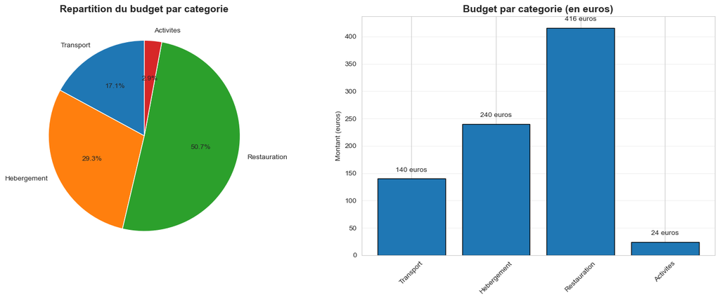

```
Budget total estime : 820.00 euros pour 2 personnes
```

```python
# Graphique camembert et barres du budget
categories = ['Transport', 'Hebergement', 'Restauration', 'Activites']
montants = [budget.transport_cout, budget.hebergement, budget.restauration, budget.activites]

fig, ax = plt.subplots(1, 2, figsize=(15, 6))

# Camembert
ax[0].pie(montants, labels=categories, autopct='%1.1f%%', startangle=90)
ax[0].set_title('Repartition du budget par categorie', fontsize=14, fontweight='bold')

# Barres
ax[1].bar(categories, montants, edgecolor='black')
ax[1].set_title('Budget par categorie (en euros)', fontsize=14, fontweight='bold')
ax[1].set_ylabel('Montant (euros)')
ax[1].tick_params(axis='x', rotation=45)
ax[1].grid(True, alpha=0.3, axis='y')

# Ajouter les valeurs sur les barres
for i, v in enumerate(montants):
    ax[1].text(i, v + 10, f"{v:.0f} euros", ha='center', va='bottom')

plt.tight_layout()
plt.show()

print(f"\nBudget total estime : {budget.total:.2f} euros pour 2 personnes")
```

## 12. Carte interactive complete

```python
# Creation de la carte finale avec tous les POIs
carte_complete = folium.Map(
    location=[paris.latitude, paris.longitude],
    zoom_start=13,
    tiles='OpenStreetMap'
)

# Marqueur de la ville
folium.Marker(
    location=[paris.latitude, paris.longitude],
    popup=f"<b>{paris.nom_ville}</b>",
    tooltip=paris.nom_ville,
    icon=folium.Icon(color='red', icon='info-sign')
).add_to(carte_complete)

# Ajouter les hotels (limites aux 5 premiers)
for hotel in hotels_paris[:5]:
    folium.Marker(
        location=[hotel.latitude, hotel.longitude],
        popup=f"<b>{hotel.nom}</b><br>{hotel.stars} etoiles - {hotel.prix_estime} euros/nuit",
        tooltip=hotel.nom,
        icon=folium.Icon(color='blue', icon='bed', prefix='fa')
    ).add_to(carte_complete)

# Ajouter les restaurants (limites aux 10 premiers)
for resto in restaurants_paris[:10]:
    couleur = 'green' if resto.type_lieu == 'restaurant' else 'orange'
    folium.Marker(
        location=[resto.latitude, resto.longitude],
        popup=f"<b>{resto.nom}</b><br>{resto.type_lieu} - {resto.prix_estime} euros",
        tooltip=resto.nom,
        icon=folium.Icon(color=couleur, icon='cutlery', prefix='fa')
    ).add_to(carte_complete)

# Ajouter les attractions (limitees aux 8 premieres)
for attr in attractions_paris[:8]:
    folium.Marker(
        location=[attr.latitude, attr.longitude],
        popup=f"<b>{attr.nom}</b><br>{attr.type_lieu}",
        tooltip=attr.nom,
        icon=folium.Icon(color='purple', icon='camera', prefix='fa')
    ).add_to(carte_complete)

# Sauvegarder la carte
carte_complete.save("data/paris_carte.html")
print("Carte sauvegardee dans data/paris_carte.html")

carte_complete
```

```
Carte sauvegardee dans data/paris_carte.html
```

Make this Notebook Trusted to load map: File -> Trust Notebook

[interactive chart not shown]

# Conclusion

## Travail realise

### Limites :

- Estimation des prix basee sur des moyennes (pas d'API gratuite pour prix reels)
- Pas d'optimisation des itineraires (calcul de distances)

### Ameliorations possibles :

- Integrer une API de prix reels (necessite abonnement payant)
- Optimiser les trajets jour par jour avec calcul de distances
- Ajouter plus de criteres de comparaison
- Systeme de recommandations base sur preferences utilisateur

## Retour d'experience

### Points positifs :

- Les APIs gratuites sont performantes et faciles a utiliser
- La conception objet facilite l'organisation du code
- Pandas et matplotlib permettent des visualisations claires
- Folium cree des cartes interactives attractives

### Difficultes rencontrees :

- API Overpass parfois lente ou en timeout
- Estimation des prix sans API dediee reste approximative
- Gestion des donnees manquantes (hotels sans etoiles, etc.)

### Apprentissages :

- Manipulation d'APIs REST
- Conception orientee objet en Python
- Visualisation de donnees avec pandas, matplotlib, seaborn, folium
- Export et traitement de donnees en CSV

# PROFIL 2 : Voyage à Lyon

## Comparaison de destinations

Pour comparer plusieurs destinations, créons un deuxième profil avec Lyon

```python
# Création rapide d'un voyage à Lyon pour comparaison
print(" Création du profil Lyon pour comparaison...")

# Ville Lyon
lyon = mv.Ville("Lyon")
lyon.recuperer_coordonnees()
print(f"✓ Lyon : {lyon.latitude}, {lyon.longitude}")

# Transport Lille-Lyon
transport_lyon = mv.Transport("train", lille, lyon)
transport_lyon.calculer_distance_duree()
transport_lyon.estimer_prix()
print(f"✓ Transport : {transport_lyon.distance} km, {transport_lyon.prix_total:.2f} €")

# Collecte rapide des données
hotels_lyon = mv.collecter_hotels(lyon, limite=20)
restaurants_lyon = mv.collecter_restaurants(lyon, limite=30)

# Création du voyage Lyon
voyage_lyon = mv.Voyage(
    utilisateur=utilisateur,
    ville=lyon,
    date_debut="2026-02-10",
    nb_jours=3,
    nb_personnes=2
)

voyage_lyon.set_transport(transport_lyon)

for h in hotels_lyon:
    voyage_lyon.ajouter_hotel(h)

for r in restaurants_lyon:
    voyage_lyon.ajouter_restaurant(r)

# Programme et budget
programme_lyon = voyage_lyon.creer_programme()
for i, jour in enumerate(programme_lyon.jours):
    if i < len(hotels_lyon):
        jour.set_hotel(hotels_lyon[i])

idx = 0
for jour in programme_lyon.jours:
    for _ in range(3):
        if idx < len(restaurants_lyon):
            jour.ajouter_restaurant(restaurants_lyon[idx])
            idx += 1

budget_lyon = voyage_lyon.calculer_budget()

print(f"\n✓ Voyage Lyon créé")
print(f"  Budget total : {budget_lyon.total:.2f} €")
```

```
🏙️ Création du profil Lyon pour comparaison...
✓ Lyon : 45.7578137, 4.8320114
Prix estime train: 167.42€ (aller-retour)
✓ Transport : 558.06 km, 167.42 €
Hotels collectes: 20
Restaurants collectes: 30

✓ Voyage Lyon créé
  Budget total : 1051.84 €
```

### Comparaison Paris vs Lyon

```python
# Utilisation du comparateur
comparateur = mv.ComparateurDestinations()
comparateur.ajouter_voyage(voyage_paris)
comparateur.ajouter_voyage(voyage_lyon)

# Obtenir la comparaison
comparaison = comparateur.comparer()

# Affichage sous forme de DataFrame
df_comparaison = pd.DataFrame(comparaison)
df_comparaison = df_comparaison.round(2)

print(" Tableau comparatif des destinations\n")
display(df_comparaison)

# Meilleure destination
print("\n Analyses :")
moins_chere = comparateur.destination_moins_chere()
print(f"  Destination la moins chère : {moins_chere['ville']} ({moins_chere['budget_total']:.2f} €)")

meilleur_rapport = comparateur.meilleur_rapport_qualite_prix()
print(f"  Meilleur rapport qualité/prix : {meilleur_rapport['ville']} (score: {meilleur_rapport['score']:.4f})")
```

```
 Tableau comparatif des destinations
```

|  | ville | nb_jours | nb_personnes | budget_transport | budget_hebergement | budget_restauration | budget_activites | budget_total | nb_hotels | nb_restaurants | nb_attractions | cout_par_jour | cout_par_personne |
| --- | --- | --- | --- | --- | --- | --- | --- | --- | --- | --- | --- | --- | --- |
| 0 | Paris | 3 | 2 | 122.88 | 265 | 416 | 0 | 803.88 | 20 | 30 | 25 | 267.96 | 401.94 |
| 1 | Lyon | 3 | 2 | 334.84 | 455 | 262 | 0 | 1051.84 | 20 | 30 | 0 | 350.61 | 525.92 |

```
 Analyses :
  Destination la moins chère : Paris (803.88 €)
  Meilleur rapport qualité/prix : Paris (score: 0.0933)
```

### Visualisation graphique de la comparaison

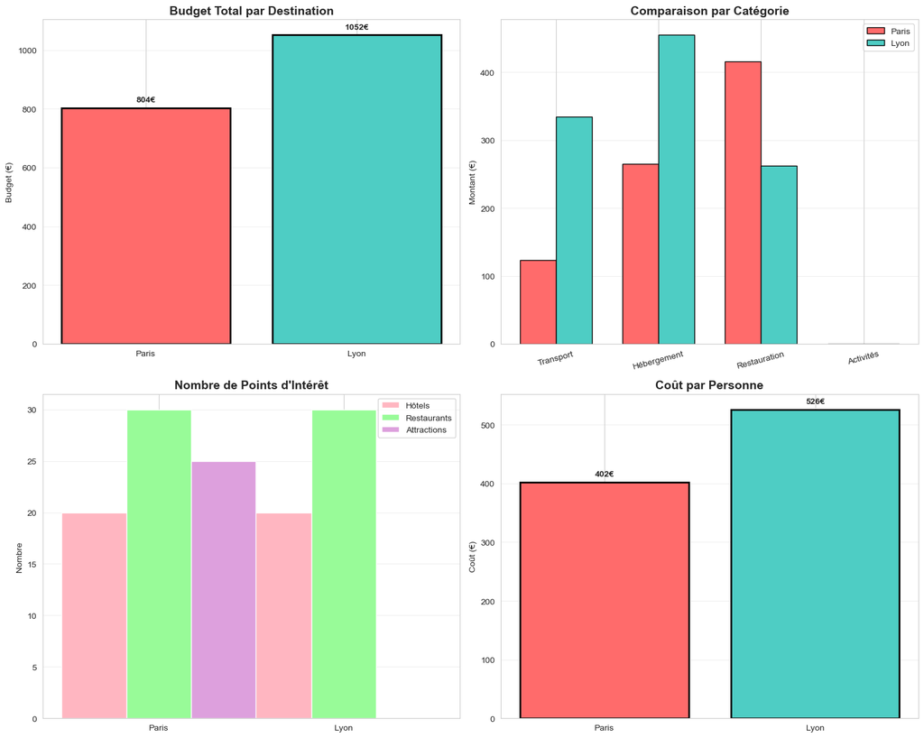

```python
# Visualisations comparatives
fig, axes = plt.subplots(2, 2, figsize=(15, 12))

# 1. Comparaison des budgets totaux
villes = [c['ville'] for c in comparaison]
budgets_totaux = [c['budget_total'] for c in comparaison]
axes[0, 0].bar(villes, budgets_totaux, color=['#FF6B6B', '#4ECDC4'], edgecolor='black', linewidth=2)
axes[0, 0].set_title('Budget Total par Destination', fontsize=14, fontweight='bold')
axes[0, 0].set_ylabel('Budget (€)')
axes[0, 0].grid(True, alpha=0.3, axis='y')
for i, v in enumerate(budgets_totaux):
    axes[0, 0].text(i, v + 20, f'{v:.0f}€', ha='center', fontweight='bold')

# 2. Comparaison par catégorie de dépenses
categories = ['Transport', 'Hébergement', 'Restauration', 'Activités']
x = range(len(categories))
width = 0.35

paris_data = [
    comparaison[0]['budget_transport'],
    comparaison[0]['budget_hebergement'],
    comparaison[0]['budget_restauration'],
    comparaison[0]['budget_activites']
]

lyon_data = [
    comparaison[1]['budget_transport'],
    comparaison[1]['budget_hebergement'],
    comparaison[1]['budget_restauration'],
    comparaison[1]['budget_activites']
]

axes[0, 1].bar([i - width/2 for i in x], paris_data, width, label='Paris', color='#FF6B6B', edgecolor='black')
axes[0, 1].bar([i + width/2 for i in x], lyon_data, width, label='Lyon', color='#4ECDC4', edgecolor='black')
axes[0, 1].set_title('Comparaison par Catégorie', fontsize=14, fontweight='bold')
axes[0, 1].set_ylabel('Montant (€)')
axes[0, 1].set_xticks(x)
axes[0, 1].set_xticklabels(categories, rotation=15)
axes[0, 1].legend()
axes[0, 1].grid(True, alpha=0.3, axis='y')

# 3. Nombre de POI disponibles
nb_hotels = [c['nb_hotels'] for c in comparaison]
nb_restos = [c['nb_restaurants'] for c in comparaison]
nb_attr = [c['nb_attractions'] for c in comparaison]

x_poi = range(len(villes))
axes[1, 0].bar([i - width for i in x_poi], nb_hotels, width, label='Hôtels', color='#FFB6C1')
axes[1, 0].bar(x_poi, nb_restos, width, label='Restaurants', color='#98FB98')
axes[1, 0].bar([i + width for i in x_poi], nb_attr, width, label='Attractions', color='#DDA0DD')
axes[1, 0].set_title('Nombre de Points d\'Intérêt', fontsize=14, fontweight='bold')
axes[1, 0].set_ylabel('Nombre')
axes[1, 0].set_xticks(x_poi)
axes[1, 0].set_xticklabels(villes)
axes[1, 0].legend()
axes[1, 0].grid(True, alpha=0.3, axis='y')

# 4. Coût par personne
cout_par_personne = [c['cout_par_personne'] for c in comparaison]
axes[1, 1].bar(villes, cout_par_personne, color=['#FF6B6B', '#4ECDC4'], edgecolor='black', linewidth=2)
axes[1, 1].set_title('Coût par Personne', fontsize=14, fontweight='bold')
axes[1, 1].set_ylabel('Coût (€)')
axes[1, 1].grid(True, alpha=0.3, axis='y')
for i, v in enumerate(cout_par_personne):
    axes[1, 1].text(i, v + 10, f'{v:.0f}€', ha='center', fontweight='bold')

plt.tight_layout()
plt.show()
```

## 11. Conclusion

### Résumé des fonctionnalités implémentées

**Collecte automatisée de données** via plusieurs APIs :

- **Nominatim** : Coordonnées GPS des villes
- **Wikipedia** : Descriptions et informations des villes
- **Overpass API** : Hôtels, restaurants et attractions
- **Open-Meteo** : Prévisions météorologiques
- **OpenRouteService** : Calcul automatique des distances et durées de transport
- **ExchangeRate-API** : Conversion de devises
- **REST Countries** : Informations sur les pays

**Programmation orientée objet** :

- Classes : Ville, Utilisateur, Transport, Hotel, Restaurant, Attraction, MeteoJour, JourProgramme, Programme, Budget, Voyage, ComparateurDestinations
- Encapsulation avec getters/setters (properties)
- Méthodes de calcul et d'estimation automatiques

**Génération de programme** :

- Programme jour par jour
- Assignation automatique des hébergements et repas
- Calcul du budget par catégorie

**Visualisations** :

- Graphiques de températures et précipitations
- Répartition des budgets (barres, camemberts)
- Comparaison de destinations
- Cartes interactives Folium avec marqueurs

**Export de données** :

- Fichiers CSV pour tous les types de données collectées
- Sauvegarde des cartes HTML

**Comparaison de destinations** :

- Analyse comparative de plusieurs villes
- Calcul du meilleur rapport qualité/prix
- Visualisations comparatives

### Améliorations possibles

- Ajout d'un scraping web pour compléter les données
- Interface graphique (Flask/Streamlit)
- Base de données pour stocker l'historique
- Système de recommandations personnalisées
- Intégration d'API de photos (Unsplash)
- Optimisation des itinéraires journaliers

```python
# Statistiques finales du projet
print(" STATISTIQUES FINALES DU PROJET\n")
print("="*60)
print(f"{'Catégorie':<30} | {'Quantité':>15}")
print("="*60)
print(f"{'Villes analysées':<30} | {2:>15}")
print(f"{'APIs utilisées':<30} | {7:>15}")
print(f"{'Hôtels collectés (total)':<30} | {len(hotels_paris) + len(hotels_lyon):>15}")
print(f"{'Restaurants collectés (total)':<30} | {len(restaurants_paris) + len(restaurants_lyon):>15}")
print(f"{'Classes Python créées':<30} | {13:>15}")
print(f"{'Fichiers CSV exportés':<30} | {'>10':>15}")
print(f"{'Cartes interactives':<30} | {1:>15}")
print("="*60)

print("\n Projet SAE 3-01 : Application MonVoyage")
print("   Développé par : LOKOUN Kris")
print("   Supervisé par : Mme BELKOUCH")
print("   Date : Janvier 2026")
```

```
 STATISTIQUES FINALES DU PROJET

============================================================
Catégorie                      |        Quantité
============================================================
Villes analysées               |               2
APIs utilisées                 |               7
Hôtels collectés (total)       |              40
Restaurants collectés (total)  |              60
Classes Python créées          |              13
Fichiers CSV exportés          |             >10
Cartes interactives            |               1
============================================================

 Projet SAE 3-01 : Application MonVoyage
   Développé par : LOKOUN Kris
   Supervisé par : Mme BELKOUCH
   Date : Janvier 2026
```